# 4/27

### ここまでの主な成果報告

・卒論を元に英語の論文を作成  
フォーマットなどどのように変更したら良いのかわからなかったので卒業論文と同じ構成にしています。  
後ほど、pdfをメールで送付します。  
Q. 数値実験のところだけ、何を組み込んだらいいか教えていただきたいです。  
今のところ、区間PCMの幅の変化とcommongroundの解ける回数については言及しています。  
→ 何かしら一つ例としてPCMの情報とその重みなどと共に既存の統合法と提案法での幅の違いやどういう場合に解が得られるようになるのかを示すことになるか？

・数値実験のバリエーション強化  
卒論時は3人のDMが5つの代替案を評価する問題を設定してiました。  
→ DMが3人よりも多くてもどの手法も同様に使えることを確認しました。  
ただし、人数が増えるほどcommonの解は得られなくなります。一例として、5代替案5DMsで1000試行しても一度も解が得られない

### 今年度の実験計画について(自分のイメージ)

研究の方向性：グループ意思決定を何かしらの全体意見を導くように完全に支援するアルゴリズムの構築を目指す

#### これまで

3手法を用いてグループ意思決定支援、区間重要度を解の非唯一性を考慮に入れて進めてきました。

・Perfect incorporation apploach(線形分数) $$ \begin{align} \begin{split} \text{minimize} ~~ & ~~ \frac{\sum_{i\in N} (w_{i}^{\rm U} - w_{i}^{\rm L})}{\sum_{i\in N} \frac {w_{i}^{\rm L} + w_{i}^{\rm U}}{2}} \\ \text{subject to} ~~ & ~~ \sum_{i\in N} (w_{ki}^{\rm U} - w_{ki}^{\rm L}) \leq \sum_{i\in N} \frac{w_{ki}^{\rm L} + w_{ki}^{\rm U}}{2}\hat{\delta}_{k} , k\in M \\ ~~ & ~~ w_{ki}^{\rm L}\leq a_{kij}w_{kj}^{U},\, a_{kij}w_{kj}^{\rm L}\leq w_{ki}^{\rm U},\, i<j, i,j\in N , k\in M\\ ~~ & ~~ \sum_{j\in N\setminus i} w_{kj}^{U} + w_{ki}^{\rm L}\geq 1, i\in N, k\in M, \\ ~~ & ~~ \sum_{j\in N\setminus i} w_{kj}^{\rm L} + w_{ki}^{\rm U}\leq 1, i\in N, k\in M, \\ ~~ & ~~ \epsilon \leq w_{i}^{\rm L}\leq w_{ki}^{\rm L}\leq w_{ki}^{\rm U} \leq w_{i}^{\rm U}, i\in N, k\in M \end{split} \end{align} $$

・Common ground apploach(線形分数) $$ \begin{align} \begin{split} \text{maximize} ~~ & ~~ \frac{\sum_{i\in N} (w_{i}^{\rm U} - w_{i}^{\rm L})}{\sum_{i\in N} \frac {w_{i}^{\rm L} + w_{i}^{\rm U}}{2}} \\ \text{subject to} ~~ & ~~ \sum_{i\in N} (w_{ki}^{\rm U} - w_{ki}^{\rm L})\leq \sum_{i\in N} \frac{w_{ki}^{\rm L} + w_{ki}^{\rm U}}{2}\hat{\delta}_{k} , k\in M \\ ~~ & ~~ w_{ki}^{\rm L}\leq a_{kij}w_{kj}^{\rm U},\, a_{kij}w_{kj}^{\rm L}\leq w_{ki}^{\rm U},\, i<j, i,j\in N , k\in M\\ ~~ & ~~ \sum_{j\in N\setminus i} w_{kj}^{\rm U} + w_{ki}^{\rm L}\geq 1, i\in N, k\in M, \\ ~~ & ~~ \sum_{j\in N\setminus i} w_{kj}^{\rm L} + w_{ki}^{\rm U}\leq 1, i\in N, k\in M, \\ ~~ & ~~ \sum_{j\in N\setminus i} w_{j}^{\rm U} + w_{i}^{\rm L}\geq 1, i\in N, \\ ~~ & ~~ \sum_{j\in N\setminus i} w_{j}^{\rm L} + w_{i}^{\rm U}\leq 1, i\in N, \\ ~~ & ~~ \epsilon \leq w_{ki}^{\rm L}\leq w_{i}^{\rm L}\leq w_{i}^{\rm U}\leq w_{ki}^{\rm U}, i\in N, k\in M \end{split} \end{align} $$

・Partial incorporation apploach(線形分数) $$ \begin{align} \begin{split} \text{minimize} ~~ & ~~ \frac{\sum_{i\in N} (w_{i}^{\rm U} - w_{i}^{\rm L})}{\sum_{i\in N} \frac {w_{i}^{\rm L} + w_{i}^{\rm U}}{2}} \\ \text{subject to} ~~ & ~~ \sum_{i\in N} (w_{ki}^{\rm U} - w_{ki}^{\rm L})\leq \sum_{i\in N} \frac{w_{ki}^{\rm L} + w_{ki}^{\rm U}}{2}\hat{\delta}_{k} , k\in M \\ ~~ & ~~ w_{ki}^{\rm L}\leq a_{kij}w_{kj}^{\rm U},\, a_{kij}w_{kj}^{\rm L}\leq w_{ki}^{\rm U},\, i<j, i,j\in N , k\in M\\ ~~ & ~~ \sum_{j\in N\setminus i} w_{kj}^{\rm U} + w_{ki}^{\rm L}\geq 1, i\in N, k\in M, \\ ~~ & ~~ \sum_{j\in N\setminus i} w_{kj}^{\rm L} + w_{ki}^{\rm U}\leq 1, i\in N, k\in M, \\ ~~ & ~~ \sum_{i\in N} w_{ki} = 1, k\in M \\ ~~ & ~~ \epsilon \leq w_{i}^{\rm L}\leq w_{ki}\leq w_{ki}^{\rm U}, \epsilon \leq w_{ki}^{\rm L}\leq w_{ki}\leq w_{i}^{\rm U}, i\in N, k\in M \end{split} \end{align} $$

#### 今後

この手法だけでもランキングを取り入れることで、実際に複数の人が関わるような意思決定問題において、  
1.perfect corporation approachによるスクリーニングによる明らかに劣る代替案の排除  
→全員の意見を広く取り入れた意見(可能な重みの組み合わせ)の中で代替案AがBに劣っていればAを意思決定から取り除ける  
全員の意見を統合しても劣っていたため排除したという理由づけも容易である

2.common ground approachによる共通意見がある場合の合意から最善策の策定

3.partial corporation approachによる共通基盤がなかった場合の妥協案の策定  
という意思決定支援アルゴリズムを考えることは可能か？

ただし、ほとんどの場合に共通部分が見つからないであろうことから、結果的にほとんどの場合で妥協案の策定に落ち着くという本来の効果的な意思決定支援の実現からは少し離れているか？  
→ 前から少し話していた意見の変更を促す方法を取り入れて、2の部分を繰り返すことで妥協案よりもより現実的な合意に近い形でより強固な意見の支援ができるのではないか

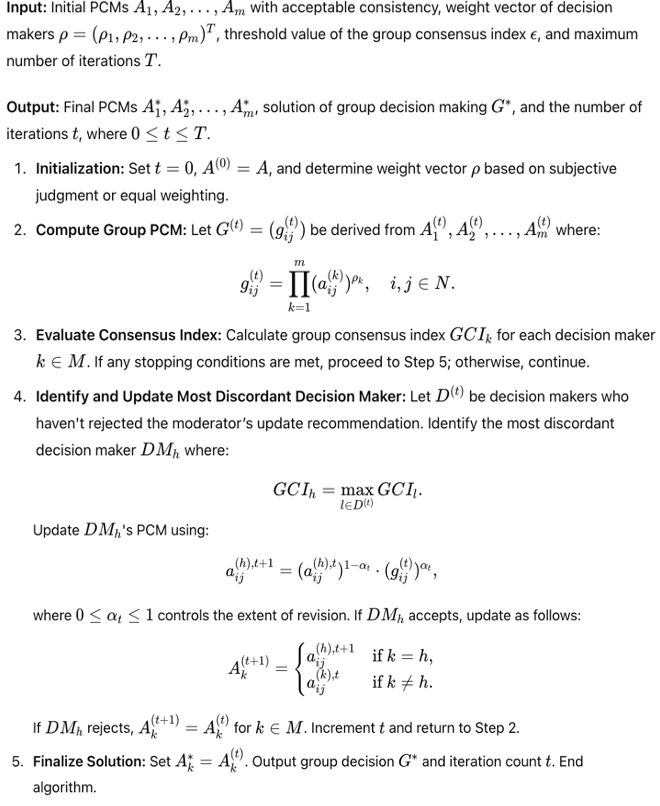

・どのように意見の変更を促すか  
→ クリスプな場合のものを参考に進める  
→ 先日お送りいただいた意見の再調整に関する論文をもとにする (5/14の雑誌会で発表予定、そこまでに目を通し理解します)  
→ それとも何かほかの方法を模索する